# L05-Alberi-di-decisione

## Uso di indice di Gini per alberi di decisione

```python
%matplotlib inline

import numpy as np
import pandas as pd
import matplotlib.pyplot as plt
from scipy.constants import golden

plt.style.use('fivethirtyeight')
plt.rc('figure', figsize=(5.0, 5.0/golden))


heroes = pd.DataFrame.from_csv('data/heroes.csv', sep=';')
```

Gli indici di eterogeneità sono alla base della costruzione di un interessante classificatore chiamato *albero di decisione*. Un albero di decisione assegna *oggetti* a *classi*, dove un oggetto è descritto tramite un'osservazione che consiste, al solito, in un vettore di valori per degli attributi prefissati. Il procedimento di classificazione procede nel modo seguente: si considera la *radice* dell'albero, cioè l'unico nodo a cui non arrivano frecce (disposto di solito in alto nella rappresentazione dell'albero), e che è contrassegnato da una condizione che coinvolge i valori di uno o più attributi per l'oggetto che si vuole classificare. A seconda del valore di questa condizione, si percorre una delle due frecce partenti dalla radice. Se il nodo a cui si arriva è un nodo terminale (una *foglia* da cui non dipartono nuove frecce), in tale nodo è indicata la classe assegnata all'oggetto, altrimenti il nodo riporta un'altra condizione da valutare, iterando il comportamento precedente fino a che non si raggiunge una foglia e quindi si determina una classe per l'oggetto.

Consideriamo per esempio l'albero riportato qui sotto, che fa riferimento a un dataset molto semplice che in funzione delle condizioni meteorologiche permette di capire se si può uscire a giocare. La radice richiede di iniziare valutando che tempo fa (attributo *Outlook*): se è nuvoloso (*overcast*) si arriva a una foglia che dice che si può uscire (*Yes*); se invece dovesse essere soleggiato viene richiesto di valutare se l'umidità abbia o meno un valore inferiore a 30; nel primo caso si potrebbe uscire, altrimenti no. Il processo di classificazione funziona in modo analogo nel caso di tempo piovoso (*rain*).

[figure not shown]

La costruzione di un albero di ricerca richiede innanzitutto di individuare un indice di eterogeneità. Facciamo un esempio selezioniamo l'indice di Gini e lavorando solo con due classi: i superori e i supercattivi, che indicheremo rispettivamente con le etichette `good_guy` e `bad_guy`. Il fatto di avere solo due etichette possibili semplifica notevolmente il calcolo dell'indice: basterà infatti specificare la frequenza relativa $f$ di `good_guy`, così che la frequenza relativa di `bad_guy` sarà $1-f$ e l'indice di Gini assumerà il valore $1 - f^2 - (1-f)^2$.

```python
def gini(f):
    return 1 - f**2 - (1-f)**2
```

Per mantenere l'albero di decisione di dimensioni compatte iniziamo selezionando alcuni supererori e alcuni supercattivi (la scelta è stata fatta anche in modo da non avere a che fare con valori mancanti, che avrebbero complicato il processo di calcolo dell'albero).

```python
good_guys = heroes.loc[['Wonder Woman', 'Aquaman', 'Cyborg', 'Flash II']]
bad_guys = heroes.loc[['Black Manta', 'Penguin', 'Joker', 'Deathstroke', 'Bizarro']]
all_guys = pd.concat([good_guys, bad_guys])
```

Estraiamo dal *dataframe* ottenuto gli attributi corrispondenti ad altezza, peso, genere, anno di prima apparizione, colore di occhi e capelli, forza e intelligenza, in quanto i rimanenti attributi sono o identici per tutti i casi selezionati o rappresentano valori univoci.

```python
features = ['Height', 'Weight', 'Gender', 'First appearance',
            'Hair color', 'Eye color', 'Strength', 'Intelligence']
X = all_guys[features]
```

Il risultato è visualizzato qui sotto.

```python
X
```

| Name | Height | Weight | Gender | First appearance | Hair color | Eye color | Strength | Intelligence |
| --- | --- | --- | --- | --- | --- | --- | --- | --- |
| Wonder Woman | 183.13 | 74.74 | F | 1941.0 | Black | Blue | 100.0 | high |
| Aquaman | 185.71 | 146.96 | M | 1941.0 | Blond | Blue | 85.0 | high |
| Cyborg | 198.12 | 173.81 | M | 1980.0 | Black | Brown | 55.0 | good |
| Flash II | 183.41 | 88.32 | M | 1956.0 | Blond | Blue | 50.0 | high |
| Black Manta | 188.12 | 92.78 | M | 1967.0 | No Hair | Black | 30.0 | good |
| Penguin | 157.89 | 79.13 | M | 1941.0 | Black | Blue | 10.0 | good |
| Joker | 196.07 | 86.91 | M | 1940.0 | Green | Green | 10.0 | high |
| Deathstroke | 193.87 | 101.98 | M | 1980.0 | White | Blue | 30.0 | good |
| Bizarro | 191.00 | 155.57 | M | 1958.0 | Black | Black | 95.0 | moderate |

```python
from sklearn.preprocessing import LabelEncoder

gender_encoder = LabelEncoder()
gender_encoder.fit(all_guys['Gender'])

eye_col_encoder = LabelEncoder()
eye_col_encoder.fit(all_guys['Eye color'])

hair_col_encoder = LabelEncoder()
hair_col_encoder.fit(all_guys['Hair color'])

intelligence_encoder = LabelEncoder()
_ = intelligence_encoder.fit(all_guys['Intelligence'])
```

```python
all_guys['Gender'] = gender_encoder.transform(all_guys['Gender'])
all_guys['Eye color'] = eye_col_encoder.transform(all_guys['Eye color'])
all_guys['Hair color'] = hair_col_encoder.transform(all_guys['Hair color'])
all_guys['Intelligence'] = intelligence_encoder.transform(all_guys['Intelligence'])
```

```python
X = all_guys[features]
X
```

| Name | Height | Weight | Gender | First appearance | Hair color | Eye color | Strength | Intelligence |
| --- | --- | --- | --- | --- | --- | --- | --- | --- |
| Wonder Woman | 183.13 | 74.74 | 0 | 1941.0 | 0 | 1 | 100.0 | 1 |
| Aquaman | 185.71 | 146.96 | 1 | 1941.0 | 1 | 1 | 85.0 | 1 |
| Cyborg | 198.12 | 173.81 | 1 | 1980.0 | 0 | 2 | 55.0 | 0 |
| Flash II | 183.41 | 88.32 | 1 | 1956.0 | 1 | 1 | 50.0 | 1 |
| Black Manta | 188.12 | 92.78 | 1 | 1967.0 | 3 | 0 | 30.0 | 0 |
| Penguin | 157.89 | 79.13 | 1 | 1941.0 | 0 | 1 | 10.0 | 0 |
| Joker | 196.07 | 86.91 | 1 | 1940.0 | 2 | 3 | 10.0 | 1 |
| Deathstroke | 193.87 | 101.98 | 1 | 1980.0 | 4 | 1 | 30.0 | 0 |
| Bizarro | 191.00 | 155.57 | 1 | 1958.0 | 0 | 0 | 95.0 | 2 |

```python
from sklearn import tree
#Y = (['good guy'] * len(justice_league)) + (['bad guy'] * len(injustice_league))
Y = pd.concat([pd.DataFrame(['good guy'] * len(good_guys), index=good_guys.index),
               pd.DataFrame(['bad guy'] * len(bad_guys), index=bad_guys.index)])
clf = tree.DecisionTreeClassifier()
clf = clf.fit(X, Y)
```

```python
clf.predict([X.iloc[0]])
```

```
array(['good guy'], dtype=object)
```

```python
def filter(obj):
    transformed_obj = obj['Height':'Intelligence']
    transformed_obj['Gender'] = gender_encoder.transform([transformed_obj['Gender']])[0]
    transformed_obj['Eye color'] = eye_col_encoder.transform([transformed_obj['Eye color']])[0]
    transformed_obj['Hair color'] = hair_col_encoder.transform([transformed_obj['Hair color']])[0]
    transformed_obj['Intelligence'] = intelligence_encoder.transform([transformed_obj['Intelligence']])[0]
    return transformed_obj
```

```python
filter(heroes.loc['Professor X'])
```

```
Height              183.74
Weight               86.89
Gender                   1
First appearance      1963
Eye color                1
Hair color               3
Strength                10
Intelligence             1
Name: Professor X, dtype: object
```

```python
clf.predict([filter(heroes.loc['Professor X'])])
```

```
array(['bad guy'], dtype=object)
```

```python
clf.predict_proba([filter(heroes.loc['Professor X'])])
```

```
array([[ 1.,  0.]])
```

```python
import graphviz

graphviz.Source(tree.export_graphviz(clf, out_file=None,
                                    class_names=['bad guy', 'good guy'],
                                    feature_names=['Height', 'Weight', 'Gender', 'First appearance', 'Hair color', 'Eye color', 'Strength', 'Intelligence']))
```

[figure not shown]

```python
Y[X.Strength <= 40]
```

| Name | 0 |
| --- | --- |
| Black Manta | bad guy |
| Penguin | bad guy |
| Joker | bad guy |
| Deathstroke | bad guy |

```python
(Y[X.Strength > 40] == 'bad guy').sum()[0]/float(len(Y[X.Strength > 40]))
```

```
0.20000000000000001
```

```python
def split_value(attribute, value):
    len_left = float(len(Y[X['{}'.format(attribute)] <= value]))
    freq = (Y[X['{}'.format(attribute)] <= value] == 'bad guy').sum()[0] / len_left
    gini_left = 1 - freq**2 - (1-freq)**2
    len_right = float(len(Y[X['{}'.format(attribute)] > value]))
    freq = (Y[X['{}'.format(attribute)] > value] == 'bad guy').sum()[0] / len_right
    gini_right = 1 - freq**2 - (1-freq)**2
    return len_left/len(Y) * gini_left + len_right/len(Y) * gini_right
```

```python
split_value('Strength', 40)
```

```
0.1777777777777777
```

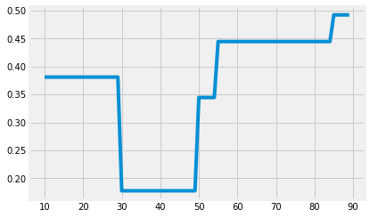

```python
plt.plot(range(10,90), map(lambda v: split_value('Strength', v), range(10,90)))
plt.show()
```